# Meeting 11 - Correlation and Linear Regression

Matthew E. Aiello-Lammens

# Today’s Goals

- Review foundations of statistical models
- Become familiar with key concepts of linear modeling
- Introduce concepts of covariation and correlation
- Identify relationship between correlation and linear regression

# Introduction to Linear Models

## Statistical Models

From Logan, p. 151:

> A **statistical model** is an expression that attempts to explain patterns in the observed values of a *response variable* by relating the response variable to a set of *predictor variables* and parameters.

A generic model looks like:

response variable = model + error

### Simple linear model

$$y = bx + a$$

where $b$ is the slope and $a$ is the y-intercept.

To make this a **statistical model** we could use the following equation:

$$y_i = \beta_0 + \beta_1 * x_i + \epsilon_i$$

Considering all data points at the same time, we can write this as:

$$Y \sim \beta_0 + \beta_1 * X + \epsilon$$

where:

$$\epsilon \sim N(0,\sigma^2)$$

## Co-variation

Let’s take a step back and ignore the potential cause-effect relationships implied by the above linear model (i.e., the model that suggests a change in $x$ results in a change in $y$). Perhaps changes in $x$ and $y$ are only *correlated* with each other, or said another way, they *co-vary* with each other.

We can measure the *strength* of this relationship as **co-variation** and/or **correlation**.

### Co-variance

This is also known as the *sum of cross-products*.

$$\frac{\sum{(x_i-\bar{x})(y_i-\bar{y})}}{n-1}$$

### Example with `iris` data

Calculate co-variation between sepal length and sepal width, using the `iris` dataset.

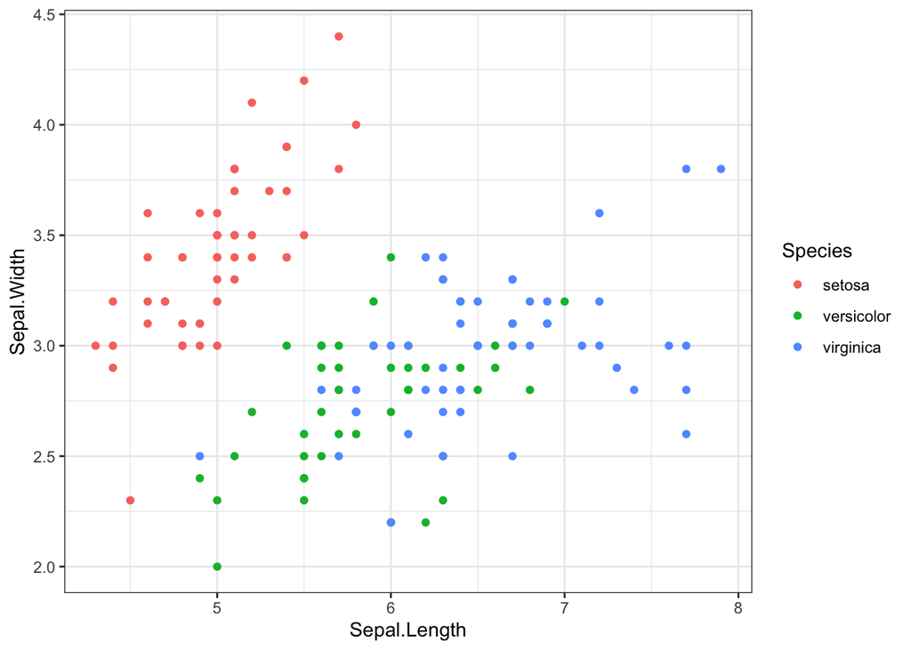

```r
data(iris)

library(ggplot2)
ggplot(data = iris) +
  geom_point(aes(x = Sepal.Length, y = Sepal.Width, colour = Species)) +
  theme_bw()
```

```r
covar <- sum((iris$Sepal.Length - mean(iris$Sepal.Length)) * (iris$Sepal.Width - mean(iris$Sepal.Width)))/ (nrow(iris) - 1)

## Confirm
var(x = iris$Sepal.Length, y = iris$Sepal.Width)
```

```
## [1] -0.042434
```

## Correlation

We can *standardize* co-variation to take on a value between -1 and 1, yielding a value called the **Pearson’s correlation coefficient** or the **product-moment coefficient**.

$$\rho_{xy} = \frac{\sum{(x_i-\bar{x})(y_i-\bar{y})}}{\sqrt{\sum{(x_i-\bar{x})^2 \sum{(y_i-\bar{y})^2}}}}$$

If we use $\hat{\bar{x}}$ and $\hat{\bar{y}}$, that is the **sample means for x and y**, then $\rho$ is represented by $r$, and called the **sample correlation coefficient statistic**. $r$ has an underlying distribution, just like other sample statistics (e.g., $t$ or $F$), which is essentially a $t$ distribution with a standard error of:

$$s_r = \sqrt{\frac{(1-r^2)}{(n-2)}}$$

Then the $t$ value is $t = \frac{r}{s_r}$.

### Example of correlation with `iris` data

Calculate the correlation between sepal length and sepal width, and calculate whether $r$ is significantly different from 0 or not.

```r
cor_iris <- covar / (sd(iris$Sepal.Length)*sd(iris$Sepal.Width))

se_cor_iris <- sqrt((1 - cor_iris^2)/(nrow(iris) - 2))

t_cor_iris <- cor_iris/se_cor_iris

## Calculate the probability of getting our t value, or one more extreme
pt(q = t_cor_iris, df = (nrow(iris)-2))*2
```

```
## [1] 0.1518983
```

```r
## Use `cor` to find correlation value
with(data = iris, cor(x = Sepal.Length, y = Sepal.Width, method = "pearson"))
```

```
## [1] -0.1175698
```

```r
## Test the correlation
with(data = iris, cor.test(x = Sepal.Length, y = Sepal.Width, method = "pearson"))
```

```
##
##  Pearson's product-moment correlation
##
## data:  Sepal.Length and Sepal.Width
## t = -1.4403, df = 148, p-value = 0.1519
## alternative hypothesis: true correlation is not equal to 0
## 95 percent confidence interval:
##  -0.27269325  0.04351158
## sample estimates:
##        cor
## -0.1175698
```

## Robust correlation

For Pearson’s correlation coefficient to be appropriate, the data should have:

1. A linear relationship
2. A bivariate normal distribution
- Spearman’s Rank Correlation - calculates correlation on ranks of observed values
- Kendall’s Rank Correlation

# Linear regression

Now we assume that any change in **y** is due to a change in **x**.

## Example of linear regression

Effects of starvation and humidity on water loss in the confused flour beetle. Here, looking at the relationship between humidity and weight loss

```r
flr_beetle <- read.csv(file = "https://mlammens.github.io/ENS-623-Research-Stats/data/Logan_Examples/Chapter8/Data/nelson.csv")
flr_beetle
```

```
##   HUMIDITY WEIGHTLOSS
## 1      0.0       8.98
## 2     12.0       8.14
## 3     29.5       6.67
## 4     43.0       6.08
## 5     53.0       5.90
## 6     62.5       5.83
## 7     75.5       4.68
## 8     85.0       4.20
## 9     93.0       3.72
```

Plot these data

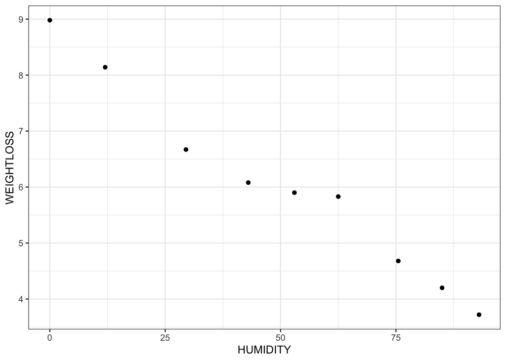

```r
library(ggplot2)
ggplot() +
  geom_point(data = flr_beetle, aes( x = HUMIDITY, y = WEIGHTLOSS)) +
  theme_bw()
```

Run a linear regression

```r
flr_beetle_lm <- lm(data = flr_beetle, WEIGHTLOSS ~ HUMIDITY)
summary(flr_beetle_lm)
```

```
##
## Call:
## lm(formula = WEIGHTLOSS ~ HUMIDITY, data = flr_beetle)
##
## Residuals:
##      Min       1Q   Median       3Q      Max
## -0.46397 -0.03437  0.01675  0.07464  0.45236
##
## Coefficients:
##              Estimate Std. Error t value Pr(>|t|)
## (Intercept)  8.704027   0.191565   45.44 6.54e-10 ***
## HUMIDITY    -0.053222   0.003256  -16.35 7.82e-07 ***
## ---
## Signif. codes:  0 '***' 0.001 '**' 0.01 '*' 0.05 '.' 0.1 ' ' 1
##
## Residual standard error: 0.2967 on 7 degrees of freedom
## Multiple R-squared:  0.9745, Adjusted R-squared:  0.9708
## F-statistic: 267.2 on 1 and 7 DF,  p-value: 7.816e-07
```

Plot these data, with `lm` fit

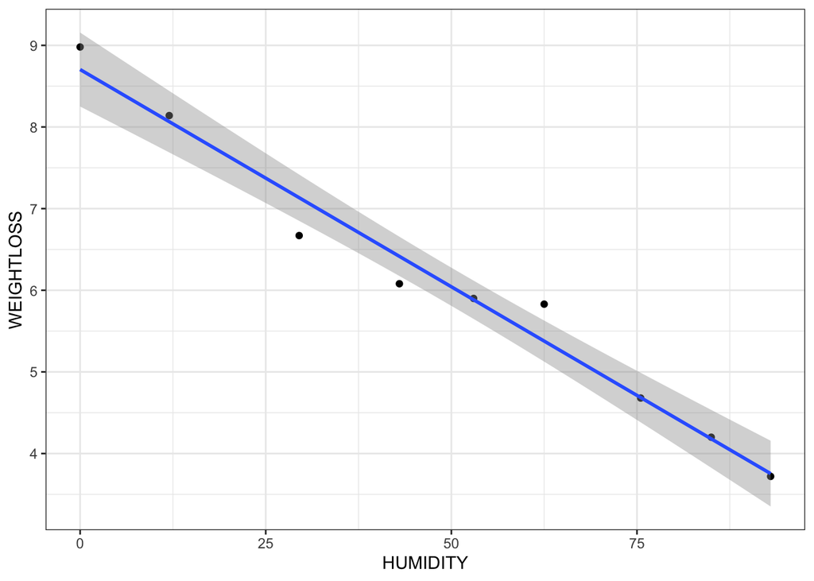

```r
ggplot(data = flr_beetle, aes( x = HUMIDITY, y = WEIGHTLOSS)) +
  geom_point() +
  stat_smooth(method = "lm") +
  theme_bw()
```

### Linear regression assumptions

#### The big three:

1. **Normality:** The $y_i$ **AND** error values ($\epsilon_i$) are normally distributed. If normality is violated, *p*-values and confidence intervals may be inaccurate and unreliable.
2. **Homogeneity of variance:** The $y_i$ **AND** error values ($\epsilon_i$) have similar levels of variance across all $x_i$ values.
3. **Independence:** The $y_i$ **AND** error values are independent of *each other*.

#### Other assumptions:

- **Linearity:** The relationship between $x_i$ and $y_i$ is linear (only important when using simple linear regression).
- **Fixed $x$ values:** The $x_i$ values are measured without error. In practice this means the error in the $x_i$ values is much smaller than that in the $y_i$ values.